# WAST3-Hausaufgabe-WI17t

Rieser Philipp

22 Dezember 2018

# Luftqualität in Zürich

Im Rahmen des Moduls Wahrscheinlichkeit und Statistik 3, untersuchen wir Anhand eines Datensatzes vom Umwelt- und Gesundheitsschutz der Stadt Zürich (UGZ) die Luftqualitätsmessungen seit dem Jahr 2012.

```r
library(tidyverse)
library(tibble)
library(knitr)
library(ggpubr)
library(purrr)
library(rlang)
library(car)
library(lubridate)
```

## 1. Import und Datenaufbereitung

Direkt nach dem einlesen

| Datum | X.Zürich.Stampfenbachstrasse | X.Zürich.Stampfenbachstrasse.1 | X.Zürich.Stampfenbachstrasse.2 | X.Zürich.Stampfenbachstrasse.3 |
| --- | --- | --- | --- | --- |
|  | Zch_Stampfenbachstrasse | Zch_Stampfenbachstrasse | Zch_Stampfenbachstrasse | Zch_Stampfenbachstrasse |
|  | Schwefeldioxid | Kohlenmonoxid | Ozon, höchstes Stundenmittel | Ozon, Anzahl Stundenmittel > 120 µg/m3 |
|  | SO2 | CO | O3_max_h1 | O3_nb_h1>120 |
|  | d1 | d1 | d1 | d1 |
|  | µg/m3 | mg/m3 | µg/m3 | 1 |
| 2012-01-01 | 1.78 | 0.31 | 43.46 | 0 |

Wie man sehen kann ist der Datensatz sehr chaotisch. In den ersten 5 Zeilen sind nur Informationen über die Messwerte gegeben und die Spalten sind lediglich nach ihren Messstationen benannt.

Zuerst werden sämtliche Spalten nach ihren jeweiligen Stationen und enthaltenen Messwerte umbenannt. Sämtliche Spalten die über den Messwert **Ozon, Anzahl Stundenmittel > 120 µg/m<sup>3</sup>** verfügen sowie die ersten fünf Zeilen werden vom Datensatz entfernt.

Ausschnitt

| Datum | Stampfenbachstrasse.SO2 | Stampfenbachstrasse.CO | Stampfenbachstrasse.O3maxh1 | Stampfenbachstrasse.NO2 |
| --- | --- | --- | --- | --- |
| 2012-01-01 | 1.78 | 0.31 | 43.46 | 26.54 |
| 2012-01-02 | 1.64 | 0.24 | 53.56 | 17.87 |
| 2012-01-03 | 1.4 | 0.24 | 66.05 | 19.62 |
| 2012-01-04 | 1.11 | 0.22 | 67.55 | 13.25 |
| 2012-01-05 | 0.9 | 0.2 | 71.45 | 10.11 |

Da das Wetter für die verschiedenen Stationen sich nicht sonderlich von einander unterscheidet, verwenden wir die Wetterdaten der Station Stampfenbachstrasse als Wetterinformation für alle Messstationen.

Für sämtliche Stationen generiert man aus den bestehenden Wetterdaten der Station Stampfenbachstrasse, Kopien und benennt diese nach der jeweiligen Station. Bei der Station Rosengartenstrasse begann man erst ab dem ersten Januar 2014 mit den Messungen. Somit erzeugt man hier eine Kopie der bis zum 01.01.2014, keine Wetterdaten aufweist.

Mit dem tidyverse-Package “tidyr” kann man nun den Datensatz in ein “long”-Format umwandeln. Dieses Format vereinfacht uns die nachfolgende Analyse.

Fertiges long-Format

| Datum | Station | Parameter | Messwert |
| --- | --- | --- | --- |
| 2012-01-01 | Stampfenbachstrasse | SO2 | 1.78 |
| 2012-01-02 | Stampfenbachstrasse | SO2 | 1.64 |
| 2012-01-03 | Stampfenbachstrasse | SO2 | 1.40 |
| 2012-01-04 | Stampfenbachstrasse | SO2 | 1.11 |
| 2012-01-05 | Stampfenbachstrasse | SO2 | 0.90 |
| 2012-01-06 | Stampfenbachstrasse | SO2 | 1.10 |

## 2. Plots

Graphische Darstellung der Messwerte:

| Stoff | Formel | Konzentration |
| --- | --- | --- |
| Schwefeldioxid | SO<sub>2</sub> | µg/m<sup>3</sup> |
| Kohlenmonoxid | CO | mg/m<sup>3</sup> |
| Stickstoffmonoxid | NO | µg/m<sup>3</sup> |
| Stickstoffdioxid | NO<sub>2</sub> | µg/m<sup>3</sup> |
| Feinstaub | PM10 | µg/m<sup>3</sup> |
| Ozon | O<sub>3</sub> | µg/m<sup>3</sup> |

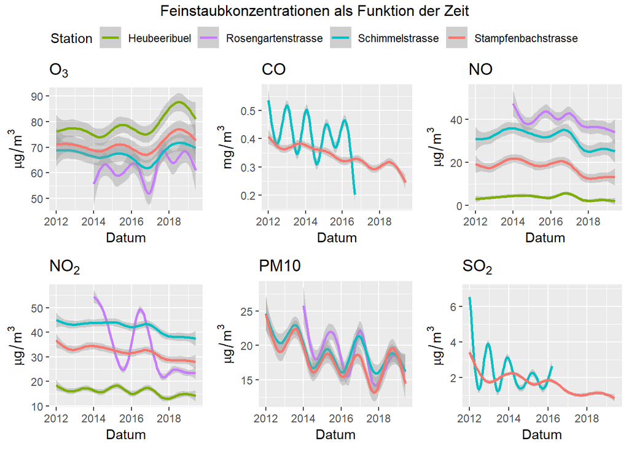

Abbildung 1

In Abbildung 1 sind die verschiedenen Stoffe der verschiedenen Stationen als Funktion der Zeit aufgetragen. Man erkennt gut, dass die Werte für O<sub>3</sub>, NO<sub>2</sub> und NO der Station Rosengartenstrasse von den anderen Stationen abweicht. Werte für CO und SO<sub>2</sub> der Schimmelstrasse varrieren stark gegenüber den Werten der Stampfenbachstrasse.

## 3. Fehlende Werte

Beachten muss man, dass die Wetterdaten jeweils von der Station Stampfenbachstrasse stammen. Somit würden die NA’s die nur von den Wetterdaten stammen insgesamt 4 Mal vorkommen.

Desweiteren muss man darauf achten, ab wann die Stationen mit den Messungen begonnen haben oder ab wann die Messungen nicht mehr weiter notiert oder sogar eingestellt wurden.

- Bei der Station Rosengartenstrasse begann man erst ab dem 01.01.2014 mit den Messungen. Zusätzlich fehlen die Werte für die Messungen von CO und SO<sub>2</sub> komplett.
- Bei der Station Schimmelstrasse wurden die Messungen der Werte für CO ab dem 31.08.2016 und für SO<sub>2</sub> ab dem 14.03.2016 nicht mehr weitergeführt.
- Bei der Station Heuberibüel fehlen die Werte für die Feinstaubmessungen von CO, PM10 und SO<sub>2</sub>.

### Effektive NA’s

- Die Stampfenbachstrasse hat 151 NA’s davon stammen 31 von den Wetterdaten.
- Die Rosengartenstrasse hat 151 NA’s ohne Wetterdaten.
- Die Schimmelstrasse hat 129 NA’s ohne Wetterdaten.
- Die Heubeeribüel hat 50 NA’s ohne Wetterdaten.

Somit verfügt der Datensatz über 481 NA’s die effektiv von nicht vorhandenen oder lediglich nicht eingetragenen Daten stammen.

Anzahl NA’s

|  | CO | NO | NO2 | O3 | PM10 | SO2 | Hr | p | RainDur | StrGlo | T | WVs |
| --- | --- | --- | --- | --- | --- | --- | --- | --- | --- | --- | --- | --- |
| Schimmelstrasse | 9 | 10 | 10 | 30 | 55 | 15 | NA | NA | NA | NA | NA | NA |
| Stampfenbachstrasse | 2 | 2 | 2 | 9 | 95 | 10 | 4 | 6 | 5 | 6 | 5 | 5 |
| Heubeeribüel | 0 | 17 | 19 | 14 | 0 | 0 | NA | NA | NA | NA | NA | NA |
| Rosengartenstrasse | 0 | 22 | 22 | 36 | 71 | 0 | NA | NA | NA | NA | NA | NA |

In der obigen Tabelle kann man die Anzahl der NA’s der einzelnen Variablen pro Station sehen.

## 4. Grenzwertüberschreitung von PM10

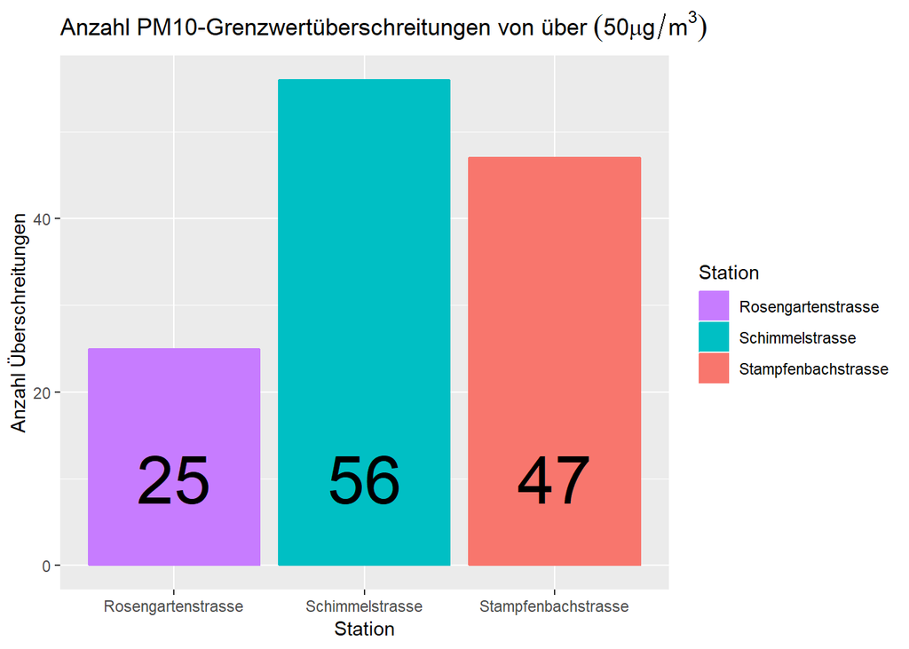

Abbildung 2

In der Abbildung 2 sind die Tagesmittel-Grenzwertüberschreitungen der jeweiligen Stationen ersichtlich. Die Station Heubeeribüel ist aufgrund von nicht vorhandenen Messwerte nicht aufgeführt.

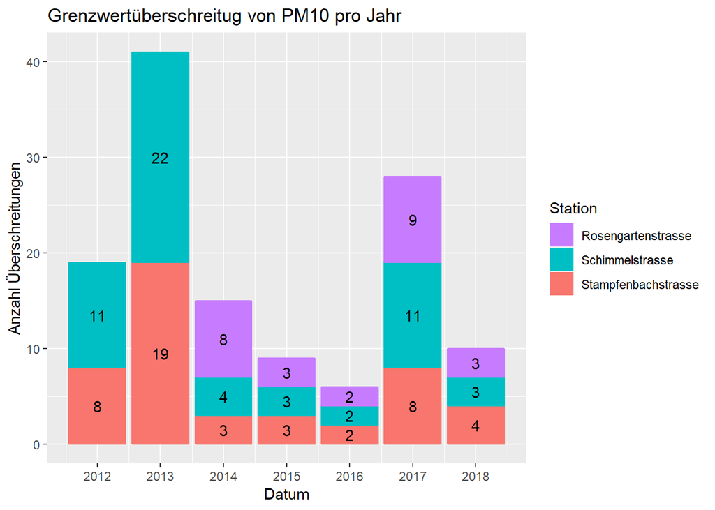

Abbildung 3

In der Abbildung 3 sind die Tagesmittel-Grenzwertüberschreitungen pro Jahr dargestellt. Auffallend ist, dass es im Jahr 2013 zu den meisten Überschreitungen kam, obwohl die Daten von nur zwei Stationen im Datensatz vorhanden sind.

### Signifikant grösser als der Zufall

Der Tagesmittel-Grenzwert darf einmal im Jahr überschritten werden. Nun möchten wir herausfinden in welchen Jahren und an welchen Stationen der Anteil der Tage mit Grenzwertüberschreitungen signifikant grösser als zufällig ist. Wir gehen davon aus, dass die Messwerte iid sind.

Man kann jeden Tag in einem Jahr als ein Bernoulli-Experiment betrachten X ~ Bin(n,p) mit **n = Anzahl Tage im Jahr** und **p = Eine Überschreitung pro Jahr**

Für jede Station wird für jedes Jahr, mit der Funktion binom.test(), ein Binomialtest durchgeführt.

|  | Rosengartenstrasse | Schimmelstrasse | Stampfenbachstrasse |
| --- | --- | --- | --- |
| 2012 | - | 3.01 | 2.19 |
| 2013 | - | 6.03 | 5.21 |
| 2014 | 2.19 | 1.1 | 0.82 |
| 2015 | 0.82 | 0.82 | 0.82 |
| 2016 | 0.55 | 0.55 | 0.55 |
| 2017 | 2.47 | 3.01 | 2.19 |
| 2018 | 0.9 | 0.9 | 1.19 |

In der obigen Tabelle sind die Punktschätzungen der Tagesmittel-Grenzwertüberschreitungen von PM10 abgebildet. Die Ausgaben der Tests wurden mit 100 multipliziert und sind gerundet.

## 5. Einflussgrössen

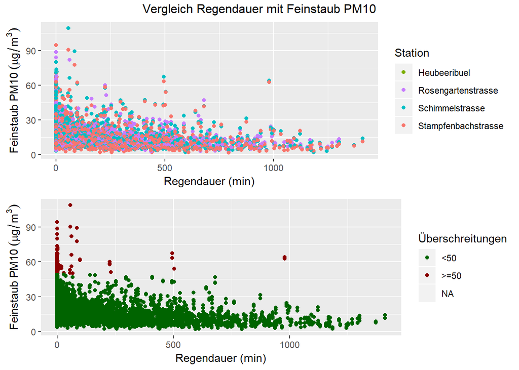

Abbildung 4

In Abbildung 4 ist der Zusammenhang der Regendauer mit der Feinstaubkonzentration PM10 abgebildet. Im oberen Plot sind die Werte der einzelnen Stationen abgebildet. Zur Ergänzung sind im unteren die PM10-Werte die den Tagesmittel-Grenzwert von 50 µg/m<sup>3</sup> überschreiten in rot aufgetragen.

Der Zusammenhang der beiden Variablen ist mittelstark, monoton fallend und negativ. Die Spearman-Korrelation weist einen Wert von -0.4967667 auf.

Trotz des mittelstarken Zusammenhangs erkennt man, dass mit einer längeren Regendauer eine kleinere Feinstaubkonzentration erwarten lässt. Ein Indiz für einen Zusammenhang kann man auch im unteren Plot erkennen. Die meisten Tagesmittel-Grenzwertüberschreitungen traten bei einer geringen Regendauer auf.

### Statistische Signifikanz

Für die weitere Analyse möchten wir folgende Frage beantworten: **Ist die Feinstaubkonzentration gemittelt über alle Messstationen statistisch signifikant tiefer an Tagen mit Regen als an Tagen ohne Regen (α = 0.01)?**

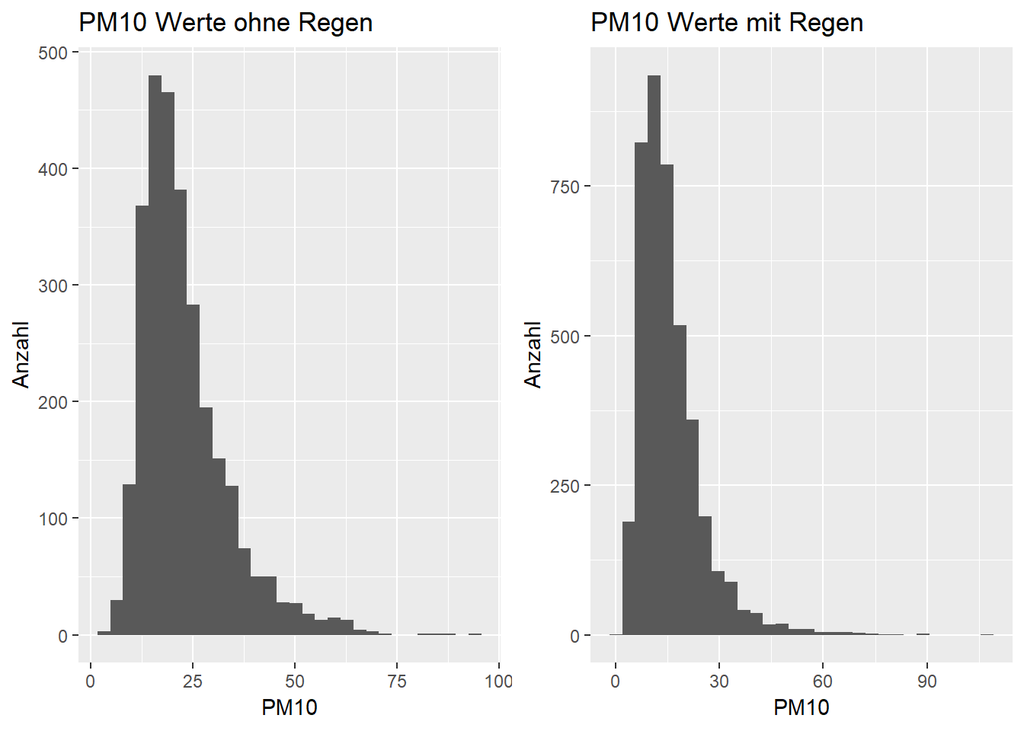

Abbildung 5

In Abbildung 5 sind die Feinstaubwerte für **mit Regen** und **ohne Regen** dargestellt. Die beiden Histogramme sind rechtsschief, da wir aber zur Überprüfung der statistischen Signifikanz eine Normalverteilung möchten, logarithmieren wir die Daten.

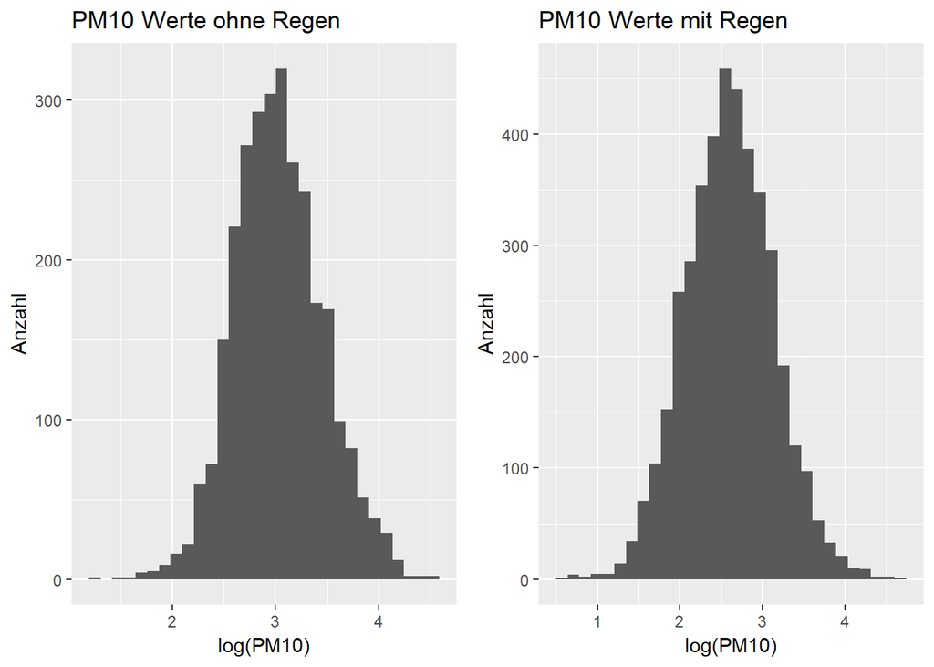

Abbildung 6

Die Werte der Histogramme in Abbildung 6 verhalten sich schon eher wie Normalverteilungen. Mit der Funktion qqPlot() aus dem Paket car lässt sich dies Überprüfen.

```
## [1] 2089 4308
```

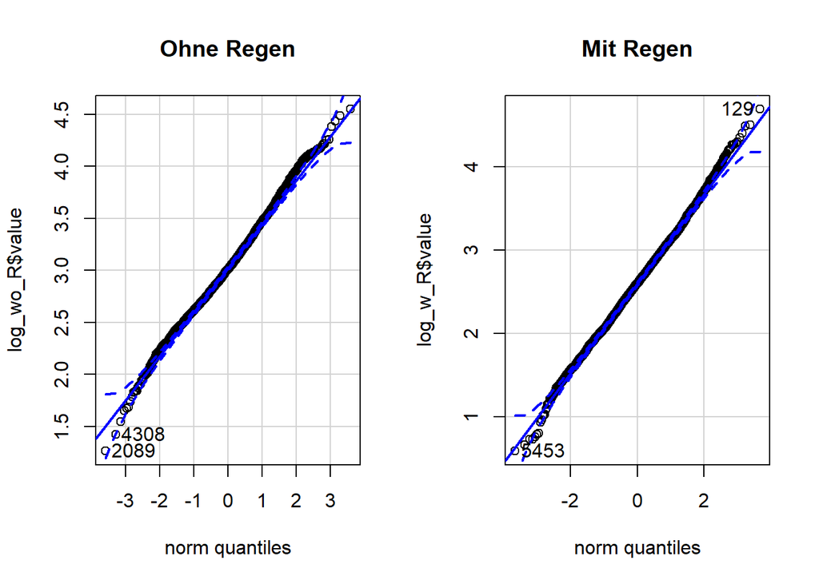

Abbildung 7

```
## [1]  129 5453
```

Wie in Abbildung 7 ersichtlich sind die logarithmierten Werte normalverteilt.

```
##
##  Two Sample t-test
##
## data:  wo_R$value and w_R$value
## t = 29.892, df = 7070, p-value < 2.2e-16
## alternative hypothesis: true difference in means is greater than 0
## 99 percent confidence interval:
##  6.603497      Inf
## sample estimates:
## mean of x mean of y
##  22.77137  15.61045
```

Die Nullhypothese H<sub>0</sub> wird verworfen, da der p-Wert kleiner ist als das Signifikanzniveau von α = 0.01. Somit kann man sagen, dass die Feinstaubkonzentration **mit Regen** signifikant tiefer ist als die **ohne Regen**.

## 6. Bevölkerungsbefragung

Unter der URL: https://zueriluft.ch/airmo/frontend/station.php?ID=11 sind Informationen über die vier Messstationen aufgelistet. Unteranderem auch der genaue Standort der Stationen. Für die Stationen Schimmelstrasse und Stampfenbachstrasse sind die Hausnummern angegeben und für die Stationen Heubeeribüel und Rosengartenstrasse sind die Koordinaten im schweizer Gitterformat angegeben. Mit diesen Informationen lassen sich die Messstationen einem Stadtkreis zuordnen.

| Station | Stadtkreis |
| --- | --- |
| Schimmelstrasse | 3 |
| Stampfenbachstrasse | 6 |
| Heubeeribüel | 7 |
| Rosengartenstrasse | 10 |

Desweiteren möchten wir untersuchen, ob die Messungen der Stationen mit der Bevölkerungsbefragung über Zufriedenheit mit dem **öffentlichen Grünraum im Quartier** korrespondieren. Die Daten der Bevölkerungsbefragung findet man unter: https://data.stadt-zuerich.ch/dataset/prd_stez_bevoelkerungsbefragung

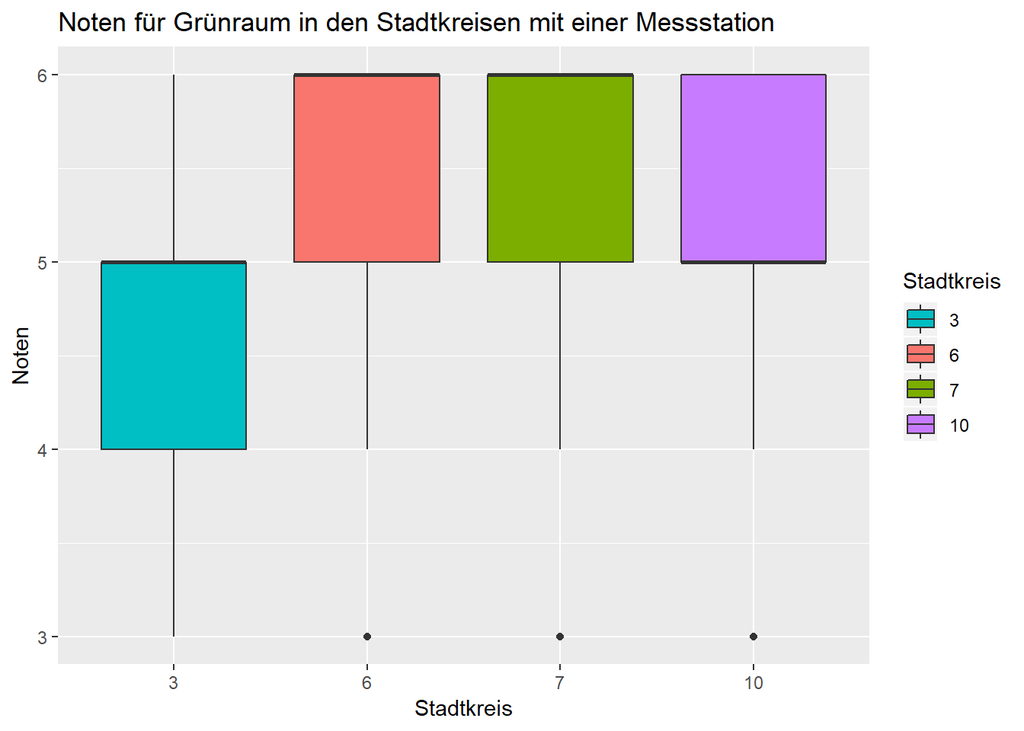

Abbildung 8

In Abbildung 8 sind die Bewertungen aus der Bevölkerungsbefragung aus den verschiedenen Stadtkreisen in welchen PM10 gemessen wurde dargestellt. Die Noten von 1-3 wurden als die Note 3 zusammengefasst.

Bis auf den Stadtkreis 3 (Station Schimmelstrasse) fallen die Bewertungen ähnlich aus. Stadtkreis 10 (Station Rosengartenstrasse) eher etwas schlechter. Der Grund, dass der Stadtkreis 3 am schlechtesten bewertet wurde, lässt sich dadruch erklären, dass es sich um das Stadtzentrum handelt, mit stark befahrenen Strassen und geschlossener Bebauung. Wahrscheinlich ist auch, dass die Begrünung durch die dichte Bebauung gegenüber den anderen Kreisen im Nachteil ist. Jedoch lässt sich dadurch kein vollendetes Fazit herleiten.

#### Summary

| Stadtkreis | count | mean | sd | median | IQR |
| --- | --- | --- | --- | --- | --- |
| 3 | 224 | 4.802691 | 0.9136561 | 5 | 1 |
| 6 | 273 | 5.468635 | 0.8465253 | 6 | 1 |
| 7 | 104 | 5.504854 | 0.7122704 | 6 | 1 |
| 10 | 381 | 5.254593 | 0.8527116 | 5 | 1 |

In der obigen Tabelle sind statistische Merkmale der Benotungen der jeweiligen Stadtkreise aufgelistet.

### Test auf Unabhängigkeit

Benotung der einzelnen Stationen

|  | Note 3 | Note 4 | Note 5 | Note 6 |
| --- | --- | --- | --- | --- |
| Schimmelstrasse (3) | 20 | 59 | 89 | 55 |
| Stampfenbachstrasse (6) | 13 | 24 | 57 | 177 |
| Heubeeribüel (7) | 2 | 7 | 31 | 63 |
| Rosengartenstrasse (10) | 20 | 42 | 140 | 179 |

In der obigen Matrix sind die Benotungen für Grünraum von jedem Stadtkreis in dem sich eine Messstation befindet aufgelistet. Um nun einen signifikanten Unterschied aus den Antworten der befragten Personen in den Stadtkreisen, in welchen Feinstaubmessungen vorgenommen wurden zu finden, wird die Heubeeribüel für die weitere Analyse nicht berücksichtigt.

Mit dem X<sup>2</sup>-Test können wir die Kontigenztafel auf Unabhängigkeit prüfen. Unsere Nullhypothese H<sub>0</sub> besteht aus den erwarteten absoluten Häufigkeiten.

Nullhypothese H0

|  | Note 3 | Note 4 | Note 5 | Note 6 |
| --- | --- | --- | --- | --- |
| Schimmelstrasse (3) | 13.50743 | 31.85714 | 72.88914 | 104.7463 |
| Stampfenbachstrasse (6) | 16.41486 | 38.71429 | 88.57829 | 127.2926 |
| Rosengartenstrasse (10) | 23.07771 | 54.42857 | 124.53257 | 178.9611 |

Mit der Funktion chisq.test() können wir weitere Annahmen treffen.

Standardisierte Residuen

|  | Note 3 | Note 4 | Note 5 | Note 6 |
| --- | --- | --- | --- | --- |
| Schimmelstrasse (3) | 1.7665682 | 4.808971 | 1.887067 | -4.8606164 |
| Stampfenbachstrasse (6) | -0.8428572 | -2.364850 | -3.355250 | 4.4057492 |
| Rosengartenstrasse (10) | -0.6406663 | -1.684643 | 1.386043 | 0.0029046 |

Es zeigt sich, dass besonders viele Bewohner des Kreises 6 ihre Zufriedenheit über Grünraum im Quartier mit der Note 6 bewerten und Bewohner des 3. Kreises mit der Note 4. Dieses Ergebnis können wir nun mit der Anzahl PM10-Tagesmittel-Grenzwertüberschreitungen in der Abbildung 3 vergleichen. Die Schimmelstrasse (Kreis 3) hat mehr Überschreitungen als die Stampfenbachstrasse (6). Somit spiegeln sich die Bewertungen des Grünraums in den Tagesmittel-Grenzwertüberschreitungen ein wenig.